# FA1

Awit, Julia Theressa and Deloyola, Jhen Reyniel L.

2026-01-29

# Exercises

## Question 1: Minimum Diamond Price

**Use dplyr to answer the following question:**

*What is the minimum diamond price in this dataset? See if you can find the answer in two different ways (i.e. using two different dplyr verbs).*

### Method 1: Using `summarise()` and `min()`

```r
# Load the diamonds dataset from ggplot2
data("diamonds")

# Method 1: Using summarise
diamonds %>%
  summarise(minimum_price = min(price))
```

```
## # A tibble: 1 × 1
##   minimum_price
##           <int>
## 1           326
```

### Method 2: Using `arrange()` and `slice()`

```r
# Method 2: Using arrange and slice
diamonds %>%
  arrange(price) %>%
  slice(1) %>%
  select(price)
```

```
## # A tibble: 1 × 1
##   price
##   <int>
## 1   326
```

### Visualization: Distribution of Diamond Prices

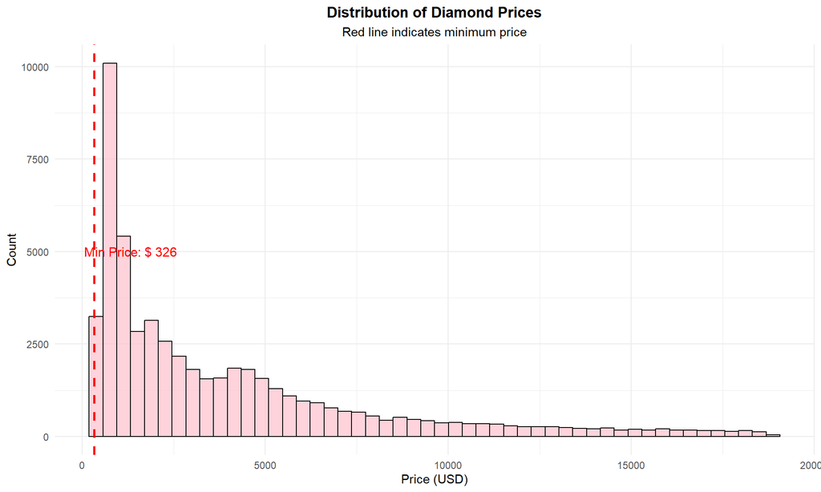

```r
# Visualize the price distribution
ggplot(diamonds, aes(x = price)) +
  geom_histogram(bins = 50, fill = "pink", color = "black", alpha = 0.7) +
  geom_vline(xintercept = min(diamonds$price), color = "red",
             linetype = "dashed", size = 1) +
  annotate("text", x = min(diamonds$price) + 1000, y = 5000,
           label = paste("Min Price: $", min(diamonds$price)),
           color = "red", size = 4) +
  labs(title = "Distribution of Diamond Prices",
       subtitle = "Red line indicates minimum price",
       x = "Price (USD)",
       y = "Count") +
  theme_minimal() +
  theme(plot.title = element_text(hjust = 0.5, face = "bold"),
        plot.subtitle = element_text(hjust = 0.5))
```

## Question 2: Diamonds with Length ≥ 1.5 × Width

*How many diamonds have length at least one and a half times their width?*

```r
# Filter diamonds where length (x) >= 1.5 * width (y)
diamonds_filtered <- diamonds %>%
  filter(x >= 1.5 * y)

# Count the number of diamonds
count_diamonds <- nrow(diamonds_filtered)

cat("Number of diamonds with length >= 1.5 × width:", count_diamonds)
```

```
## Number of diamonds with length >= 1.5 × width: 10
```

### Visualization: Length vs Width Ratio

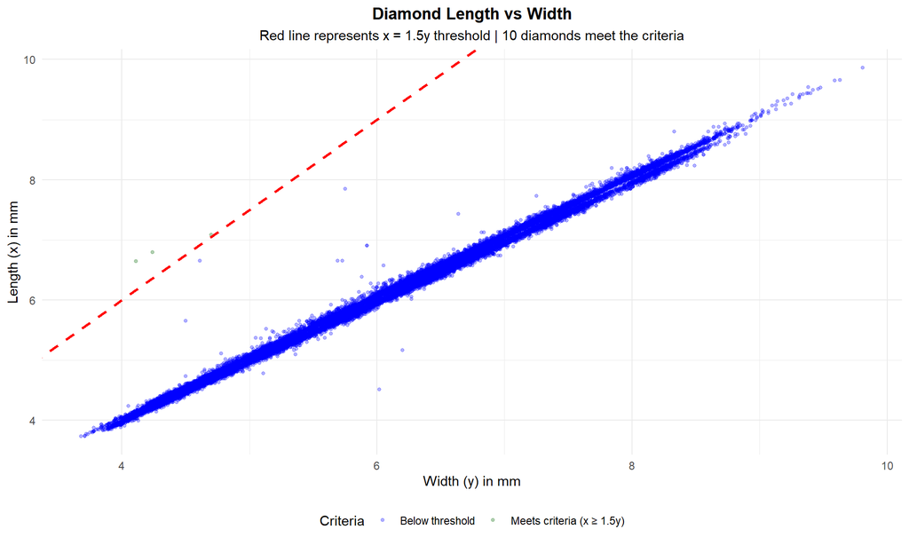

```r
# Create a scatter plot showing the relationship
diamonds %>%
  mutate(ratio = x / y,
         meets_criteria = x >= 1.5 * y) %>%
  filter(x > 0 & y > 0 & x < 10 & y < 10) %>%  # Remove outliers
  ggplot(aes(x = y, y = x, color = meets_criteria)) +
  geom_point(alpha = 0.3, size = 1) +
  geom_abline(slope = 1.5, intercept = 0, color = "red",
              linetype = "dashed", size = 1) +
  scale_color_manual(values = c("FALSE" = "blue", "TRUE" = "darkgreen"),
                     labels = c("FALSE" = "Below threshold",
                                "TRUE" = "Meets criteria (x ≥ 1.5y)")) +
  labs(title = "Diamond Length vs Width",
       subtitle = paste("Red line represents x = 1.5y threshold |",
                       count_diamonds, "diamonds meet the criteria"),
       x = "Width (y) in mm",
       y = "Length (x) in mm",
       color = "Criteria") +
  theme_minimal() +
  theme(plot.title = element_text(hjust = 0.5, face = "bold"),
        plot.subtitle = element_text(hjust = 0.5),
        legend.position = "bottom")
```

## Question 3: Median Carats by Cut

*Among diamonds with colors D, E, F, G, what is the median number of carats for diamonds of each cut?*

```r
# Filter for colors D, E, F, G and calculate median carats by cut
median_carats <- diamonds %>%
  filter(color %in% c("D", "E", "F", "G")) %>%
  group_by(cut) %>%
  summarise(median_carat = median(carat),
            count = n()) %>%
  arrange(desc(median_carat))

# Display the results
print(median_carats)
```

```
## # A tibble: 5 × 3
##   cut       median_carat count
##   <ord>            <dbl> <int>
## 1 Fair              0.91  1013
## 2 Good              0.72  3375
## 3 Premium           0.71  9195
## 4 Very Good         0.7   8376
## 5 Ideal             0.52 15447
```

### Visualization: Median Carats by Cut

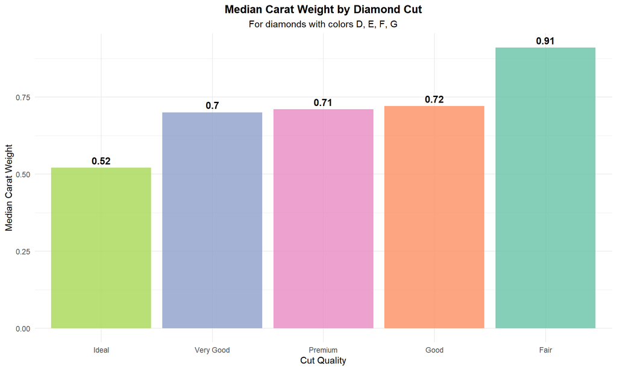

```r
# Create a bar plot
ggplot(median_carats, aes(x = reorder(cut, median_carat), y = median_carat,
                          fill = cut)) +
  geom_col(show.legend = FALSE, alpha = 0.8) +
  geom_text(aes(label = round(median_carat, 3)),
            vjust = -0.5, size = 4, fontface = "bold") +
  scale_fill_brewer(palette = "Set2") +
  labs(title = "Median Carat Weight by Diamond Cut",
       subtitle = "For diamonds with colors D, E, F, G",
       x = "Cut Quality",
       y = "Median Carat Weight") +
  theme_minimal() +
  theme(plot.title = element_text(hjust = 0.5, face = "bold"),
        plot.subtitle = element_text(hjust = 0.5),
        axis.text.x = element_text(angle = 0, hjust = 0.5))
```

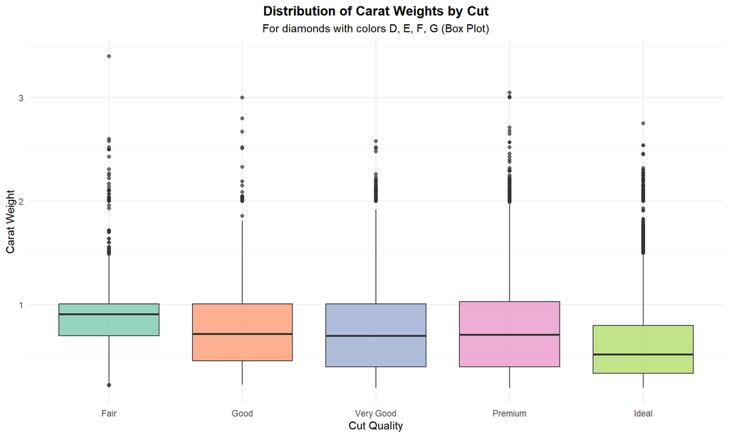

```r
# Box plot for additional context
diamonds %>%
  filter(color %in% c("D", "E", "F", "G")) %>%
  ggplot(aes(x = cut, y = carat, fill = cut)) +
  geom_boxplot(alpha = 0.7, show.legend = FALSE) +
  scale_fill_brewer(palette = "Set2") +
  labs(title = "Distribution of Carat Weights by Cut",
       subtitle = "For diamonds with colors D, E, F, G (Box Plot)",
       x = "Cut Quality",
       y = "Carat Weight") +
  theme_minimal() +
  theme(plot.title = element_text(hjust = 0.5, face = "bold"),
        plot.subtitle = element_text(hjust = 0.5))
```

## Question 4: Why Does This Code Fail?

**Exercise 1: Why does this code fail?**

```r
# This code will produce an error
table4a %>%
  pivot_longer(cols = c(1999, 2000), names_to = "year", values_to = "cases")
```

```
## Error in `pivot_longer()`:
## ! Can't select columns past the end.
## ℹ Locations 1999 and 2000 don't exist.
## ℹ There are only 3 columns.
```

**Answer:**

The code fails because `1999` and `2000` are being treated as column positions (numeric indices), not column names. When using bare column names in `pivot_longer()`, R interprets numeric values as positions rather than column names.

**Solution:**

```r
# Load table4a from tidyr
data("table4a")

# Correct way: Use backticks or quotes for numeric column names
table4a %>%
  pivot_longer(cols = c(`1999`, `2000`), names_to = "year", values_to = "cases")
```

```
## # A tibble: 6 × 3
##   country     year   cases
##   <chr>       <chr>  <dbl>
## 1 Afghanistan 1999     745
## 2 Afghanistan 2000    2666
## 3 Brazil      1999   37737
## 4 Brazil      2000   80488
## 5 China       1999  212258
## 6 China       2000  213766
```

```r
# Alternative: Use quotes
table4a %>%
  pivot_longer(cols = c("1999", "2000"), names_to = "year", values_to = "cases")
```

```
## # A tibble: 6 × 3
##   country     year   cases
##   <chr>       <chr>  <dbl>
## 1 Afghanistan 1999     745
## 2 Afghanistan 2000    2666
## 3 Brazil      1999   37737
## 4 Brazil      2000   80488
## 5 China       1999  212258
## 6 China       2000  213766
```

## Question 5: Tidy the Tibble

**Exercise 2: Tidy the simple tibble below. Do you need to make it wider or longer? What are the variables?**

```r
# Create the original tibble
preg_data <- tribble(
  ~pregnant, ~male, ~female,
  "yes",     NA,    10,
  "no",      20,    12
)

print("Original tibble:")
```

```
## [1] "Original tibble:"
```

```r
print(preg_data)
```

```
## # A tibble: 2 × 3
##   pregnant  male female
##   <chr>    <dbl>  <dbl>
## 1 yes         NA     10
## 2 no          20     12
```

**Answer:**

- **Direction**: The tibble needs to be made **longer**
- **Variables**:
  - `sex` (male/female)
  - `pregnant` (yes/no)
  - `count` (the numeric values)

```r
# Tidy the data
preg_tidy <- preg_data %>%
  pivot_longer(cols = c(male, female),
               names_to = "sex",
               values_to = "count")

print("Tidied tibble:")
```

```
## [1] "Tidied tibble:"
```

```r
print(preg_tidy)
```

```
## # A tibble: 4 × 3
##   pregnant sex    count
##   <chr>    <chr>  <dbl>
## 1 yes      male      NA
## 2 yes      female    10
## 3 no       male      20
## 4 no       female    12
```

### Visualization: Pregnancy Status by Sex

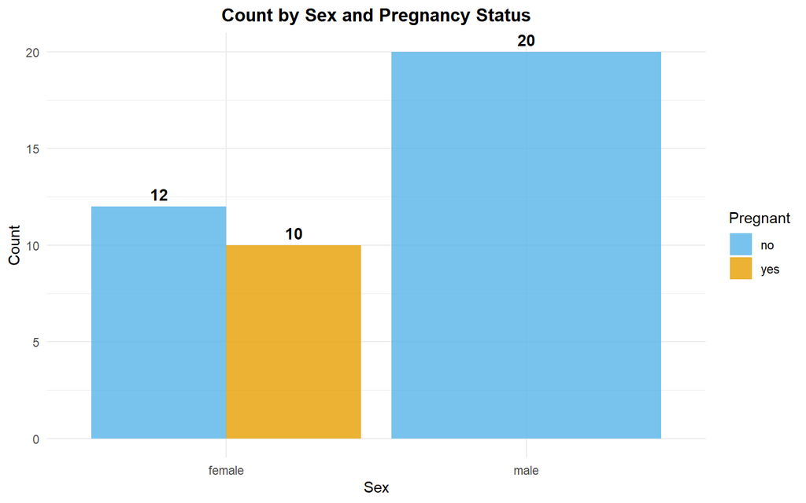

```r
# Visualize the tidied data
preg_tidy %>%
  filter(!is.na(count)) %>%
  ggplot(aes(x = sex, y = count, fill = pregnant)) +
  geom_col(position = "dodge", alpha = 0.8) +
  geom_text(aes(label = count), position = position_dodge(width = 0.9),
            vjust = -0.5, size = 4, fontface = "bold") +
  scale_fill_manual(values = c("yes" = "#E69F00", "no" = "#56B4E9")) +
  labs(title = "Count by Sex and Pregnancy Status",
       x = "Sex",
       y = "Count",
       fill = "Pregnant") +
  theme_minimal() +
  theme(plot.title = element_text(hjust = 0.5, face = "bold"),
        legend.position = "right")
```

**Note**: The NA value for male/yes is expected since males cannot be pregnant. This represents a structural missing value rather than a data quality issue.